# Time Series & Econometrics

TD5

# *Part 1 : Warm up - Data settings and unit root tests*

## *Exercise 1 : Data settings*

### 1. Data importation can be automated using R features and packages. There exists several API facilitating economic and financial import and update. Load the Advance Retail Sales - namely the Retail Trade from the Federal Reserve of Saint Louis ?

```r
library(eFRED)
rs <- fred("RSXFSN", all= FALSE)
head(rs)
```

```
##         date RSXFSN
## 1 1992-01-01 130683
## 2 1992-02-01 131244
## 3 1992-03-01 142488
## 4 1992-04-01 147175
## 5 1992-05-01 152420
## 6 1992-06-01 151849
```

### 2. Check the status of the imported data and transform it into a right object if necessary. Plot the data. What do you observe ? What type of seasonal pattern is ? What type of the filters do you propose to clean the retail sales.

```r
sapply(rs, typeof)
```

```
##     date   RSXFSN
## "double" "double"
```

```r
str(rs)
```

```
## 'data.frame':    370 obs. of  2 variables:
##  $ date  : Date, format: "1992-01-01" "1992-02-01" ...
##  $ RSXFSN: num  130683 131244 142488 147175 152420 ...
##  - attr(*, "info")='data.frame': 1 obs. of  16 variables:
##   ..$ id                       : chr "RSXFSN"
##   ..$ realtime_start           : Date[1:1], format: "2022-12-04"
##   ..$ realtime_end             : Date[1:1], format: "2022-12-04"
##   ..$ title                    : chr "Advance Retail Sales: Retail Trade"
##   ..$ observation_start        : Date[1:1], format: "1992-01-01"
##   ..$ observation_end          : Date[1:1], format: "2022-10-01"
##   ..$ frequency                : chr "Monthly"
##   ..$ frequency_short          : chr "M"
##   ..$ units                    : chr "Millions of Dollars"
##   ..$ units_short              : chr "Mil. of $"
##   ..$ seasonal_adjustment      : chr "Not Seasonally Adjusted"
##   ..$ seasonal_adjustment_short: chr "NSA"
##   ..$ last_updated             : POSIXct[1:1], format: "2022-11-16 07:34:03"
##   ..$ popularity               : int 40
##   ..$ notes                    : chr "E-commerce sales are included in the total monthly sales estimates. \n\nThe value for the most recent month is "| __truncated__
##   ..$ group                    : chr "RSXFSN"
```

> We can see that the data is clean and usable.

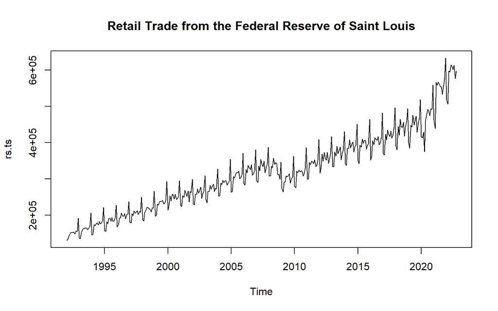

```r
rs.ts <- ts(rs$RSXFSN, start= c(1992, 01), frequency= 12)
ts.plot(rs.ts, main= "Retail Trade from the Federal Reserve of Saint Louis")
```

### 3. Run the required filter to cut the seasonal pattern ? You can choose between the seasonal regression, the moving average filter and the decompose function (this function is based on moving average seasonal filters as well).

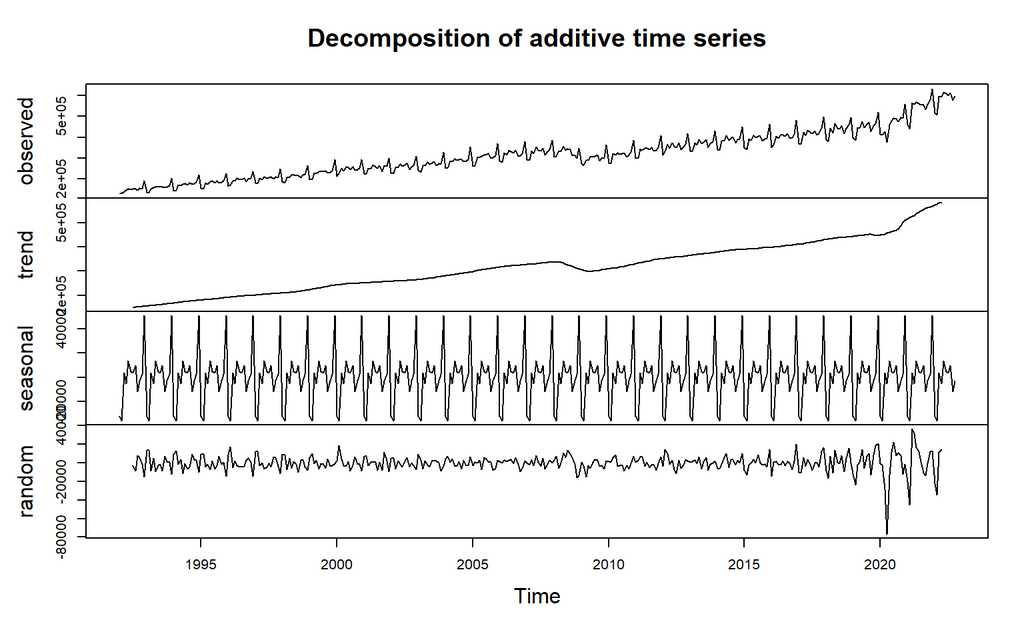

```r
dec.rs <- decompose(rs.ts)
plot(dec.rs)
```

### 4. Grab the filtered data and check using the right tool the seasonal pattern has been deleted. Is this filtered data be modeled using an ARMA(p,q) approach ?

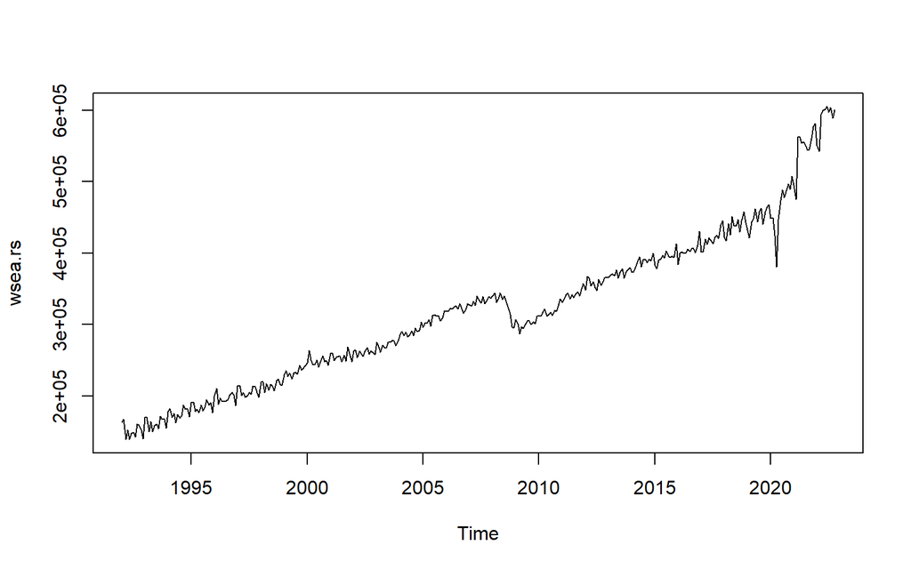

```r
library(forecast)
wsea.rs <- seasadj(dec.rs)
plot(wsea.rs)
```

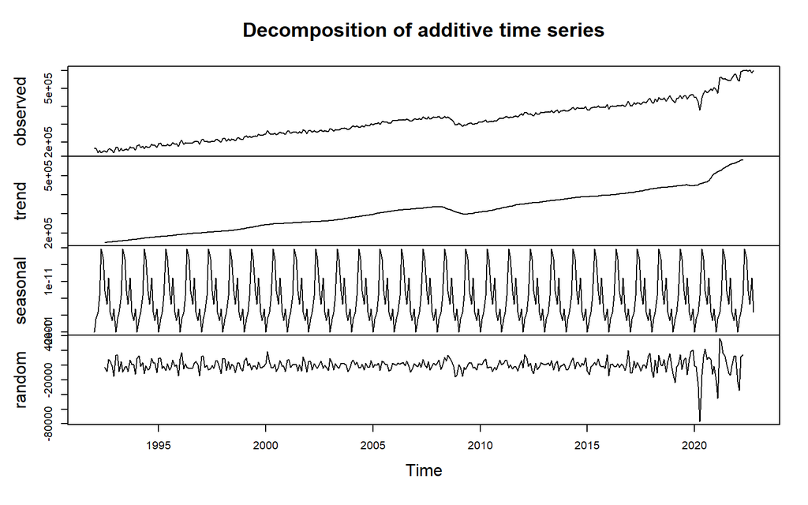

```r
plot(decompose(wsea.rs))
```

> We can observe that the series seems purged of its seasonality. Indeed, e can observe too slight a seasonality to consider it as such (order of magnitude: 10^(-11)). In addition, we can now observe the trend and the noise of the time series. This trend implies a non-stationarity of the time series and thus an impossibility to model the Retail Sales time series by an ARMA(p,q).

## *Exercise 2 : Unit Root tests*

We can notice the seasonally adjusted data (or the filtered one) is still showing an upward trend. We need to characterize this positive trend, i.e. whether it is a trend stationary or a stochastic trend.

### 1. Load the “urca” package. Summarize quickly the step-wise approach of the Dickey Fuller test.

Compute the Augmented Dickey Fuller test using the right function on the filtered data (note that the selection of the number of lags can be performed on a discretionary way or automatically).

> The DF (Dickey Fuller 1979) and ADF (Augmented Dickey Fuller 1981) tests are unit root tests to test the stationarity of the time series. The difference is that ADF takes into account the autocorrelation of the estimated residuals and a data generating process. We are interested in the ADF, which is the following model: ∆yt = β1 + β2t + πyt−1 + ∑ γi∆t−i + ut

> We test two hypotheses: - H0: π=0 - H1: π<0 If we reject H0, then there is no unit root which implies that the time series is not stationary. Conversely, if we do not reject H0, there is a unit root which implies that the process is stationary (according to our confidence interval).

> The ADF test follows a step-by-step process: ∆yt = β1 + β2t + πyt−1 + ∑ γi∆t−i + ut Step 1: Test if π=0. If not, end of test and there is no unit root. If yes, go to step 2. Step 2: Test if β2=0. If no, end of test and there is a unit root. If yes, change the model: ∆yt = β1 + πyt−1 + ∑ γi∆t−i + ut Step 3: Test if π=0. If no, end of test and there is no unit root. If yes, go to step 4. Step 4: Test if β1=0. If no, end of test and there is a unit root. If yes, change the model: ∆yt = πyt-1 + ∑ γi∆t-i + ut Step 5: Test if π=0. If no, there is finally no unit root and if yes, there is finally a unit root.

> Let’s start by performing the ADF test manually: For a lag= 1 and type= “trend” because we can observe one, we have:

```r
library(urca)
ADF1t <- ur.df(wsea.rs, type= "trend", lag= 1)
summary(ADF1t)
```

```
##
## ###############################################
## # Augmented Dickey-Fuller Test Unit Root Test #
## ###############################################
##
## Test regression trend
##
##
## Call:
## lm(formula = z.diff ~ z.lag.1 + 1 + tt + z.diff.lag)
##
## Residuals:
##    Min     1Q Median     3Q    Max
## -55574  -6702    355   5557  79266
##
## Coefficients:
##               Estimate Std. Error t value Pr(>|t|)
## (Intercept) 7768.69493 3487.62553   2.228   0.0265 *
## z.lag.1       -0.05498    0.02365  -2.325   0.0206 *
## tt            60.39224   23.55710   2.564   0.0108 *
## z.diff.lag    -0.25269    0.05175  -4.883 1.57e-06 ***
## ---
## Signif. codes:  0 '***' 0.001 '**' 0.01 '*' 0.05 '.' 0.1 ' ' 1
##
## Residual standard error: 11520 on 364 degrees of freedom
## Multiple R-squared:  0.09655,    Adjusted R-squared:  0.0891
## F-statistic: 12.97 on 3 and 364 DF,  p-value: 4.585e-08
##
##
## Value of test-statistic is: -2.3246 4.4138 3.5192
##
## Critical values for test statistics:
##       1pct  5pct 10pct
## tau3 -3.98 -3.42 -3.13
## phi2  6.15  4.71  4.05
## phi3  8.34  6.30  5.36
```

> We can see that 1 lag is significant. Let’s test with lag= 2:

```r
ADF2t <- ur.df(wsea.rs, type= "trend", lag= 2)
summary(ADF2t)
```

```
##
## ###############################################
## # Augmented Dickey-Fuller Test Unit Root Test #
## ###############################################
##
## Test regression trend
##
##
## Call:
## lm(formula = z.diff ~ z.lag.1 + 1 + tt + z.diff.lag)
##
## Residuals:
##    Min     1Q Median     3Q    Max
## -57151  -6054    259   5053  72872
##
## Coefficients:
##               Estimate Std. Error t value Pr(>|t|)
## (Intercept) 3225.35654 3408.30944   0.946    0.345
## z.lag.1       -0.01968    0.02324  -0.847    0.398
## tt            27.25327   23.04659   1.183    0.238
## z.diff.lag1   -0.35470    0.05233  -6.778 4.96e-11 ***
## z.diff.lag2   -0.29730    0.05119  -5.808 1.38e-08 ***
## ---
## Signif. codes:  0 '***' 0.001 '**' 0.01 '*' 0.05 '.' 0.1 ' ' 1
##
## Residual standard error: 10970 on 362 degrees of freedom
## Multiple R-squared:  0.1717, Adjusted R-squared:  0.1626
## F-statistic: 18.76 on 4 and 362 DF,  p-value: 4.962e-14
##
##
## Value of test-statistic is: -0.8469 5.1351 1.5249
##
## Critical values for test statistics:
##       1pct  5pct 10pct
## tau3 -3.98 -3.42 -3.13
## phi2  6.15  4.71  4.05
## phi3  8.34  6.30  5.36
```

> We can see that 2 lags are significant. Let’s test with lag= 3:

```r
ADF3t <- ur.df(wsea.rs, type= "trend", lag= 3)
summary(ADF3t)
```

```
##
## ###############################################
## # Augmented Dickey-Fuller Test Unit Root Test #
## ###############################################
##
## Test regression trend
##
##
## Call:
## lm(formula = z.diff ~ z.lag.1 + 1 + tt + z.diff.lag)
##
## Residuals:
##    Min     1Q Median     3Q    Max
## -58809  -6008    397   4948  73032
##
## Coefficients:
##               Estimate Std. Error t value Pr(>|t|)
## (Intercept) 2406.95029 3484.56394   0.691    0.490
## z.lag.1       -0.01393    0.02386  -0.584    0.560
## tt            22.43402   23.55183   0.953    0.341
## z.diff.lag1   -0.37579    0.05667  -6.631 1.22e-10 ***
## z.diff.lag2   -0.32267    0.05600  -5.762 1.79e-08 ***
## z.diff.lag3   -0.06134    0.05361  -1.144    0.253
## ---
## Signif. codes:  0 '***' 0.001 '**' 0.01 '*' 0.05 '.' 0.1 ' ' 1
##
## Residual standard error: 10980 on 360 degrees of freedom
## Multiple R-squared:  0.1727, Adjusted R-squared:  0.1612
## F-statistic: 15.03 on 5 and 360 DF,  p-value: 2.054e-13
##
##
## Value of test-statistic is: -0.5838 5.4489 1.5433
##
## Critical values for test statistics:
##       1pct  5pct 10pct
## tau3 -3.98 -3.42 -3.13
## phi2  6.15  4.71  4.05
## phi3  8.34  6.30  5.36
```

### 2. Determine then the integration degree of the data ?

> The degree of integration of a series corresponds to the number of times a differentiation filter is applied to stationarize it. So, let’s apply the filter once:

```r
dt1.rs <- diff(wsea.rs)
summary(ur.df(dt1.rs, type= "trend", lags= 1))
```

```
##
## ###############################################
## # Augmented Dickey-Fuller Test Unit Root Test #
## ###############################################
##
## Test regression trend
##
##
## Call:
## lm(formula = z.diff ~ z.lag.1 + 1 + tt + z.diff.lag)
##
## Residuals:
##    Min     1Q Median     3Q    Max
## -56709  -5859    626   5176  72462
##
## Coefficients:
##               Estimate Std. Error t value Pr(>|t|)
## (Intercept)  518.54776 1151.88712   0.450    0.653
## z.lag.1       -1.67671    0.07942 -21.111  < 2e-16 ***
## tt             8.28323    5.42146   1.528    0.127
## z.diff.lag     0.30776    0.04966   6.197 1.56e-09 ***
## ---
## Signif. codes:  0 '***' 0.001 '**' 0.01 '*' 0.05 '.' 0.1 ' ' 1
##
## Residual standard error: 10970 on 363 degrees of freedom
## Multiple R-squared:  0.6787, Adjusted R-squared:  0.676
## F-statistic: 255.5 on 3 and 363 DF,  p-value: < 2.2e-16
##
##
## Value of test-statistic is: -21.1115 148.5868 222.87
##
## Critical values for test statistics:
##       1pct  5pct 10pct
## tau3 -3.98 -3.42 -3.13
## phi2  6.15  4.71  4.05
## phi3  8.34  6.30  5.36
```

### 3. Compute the Phillips and Perron test on the filtered data. Does it confirm your previous result ?

> We choose model= “trend” beacause there is a trend. ∆yt = βt + πyt−1 + ∑ γi∆t−i + ut

```r
PP <- ur.pp(wsea.rs, type= "Z-tau", model= "trend", use.lag= 1)
summary(PP)
```

```
##
## ##################################
## # Phillips-Perron Unit Root Test #
## ##################################
##
## Test regression with intercept and trend
##
##
## Call:
## lm(formula = y ~ y.l1 + trend)
##
## Residuals:
##    Min     1Q Median     3Q    Max
## -50100  -7069    147   5719  84779
##
## Coefficients:
##              Estimate Std. Error t value Pr(>|t|)
## (Intercept) 2.812e+04  7.476e+03   3.761 0.000197 ***
## y.l1        9.152e-01  2.347e-02  38.994  < 2e-16 ***
## trend       8.778e+01  2.346e+01   3.741 0.000212 ***
## ---
## Signif. codes:  0 '***' 0.001 '**' 0.01 '*' 0.05 '.' 0.1 ' ' 1
##
## Residual standard error: 11860 on 366 degrees of freedom
## Multiple R-squared:  0.9879, Adjusted R-squared:  0.9878
## F-statistic: 1.488e+04 on 2 and 366 DF,  p-value: < 2.2e-16
##
##
## Value of test-statistic, type: Z-tau  is: -3.0309
##
##            aux. Z statistics
## Z-tau-mu              5.3337
## Z-tau-beta            3.1930
##
## Critical values for Z statistics:
##                      1pct      5pct     10pct
## critical values -3.986785 -3.423677 -3.134509
```

```r
summary(ur.pp(dt1.rs, type= "Z-tau", model= "trend", use.lag= 1))
```

```
##
## ##################################
## # Phillips-Perron Unit Root Test #
## ##################################
##
## Test regression with intercept and trend
##
##
## Call:
## lm(formula = y ~ y.l1 + trend)
##
## Residuals:
##    Min     1Q Median     3Q    Max
## -54082  -6656    479   5430  78720
##
## Coefficients:
##               Estimate Std. Error t value Pr(>|t|)
## (Intercept) 1502.40536  606.95925   2.475   0.0138 *
## y.l1          -0.28438    0.05022  -5.663 3.02e-08 ***
## trend          7.23584    5.69327   1.271   0.2046
## ---
## Signif. codes:  0 '***' 0.001 '**' 0.01 '*' 0.05 '.' 0.1 ' ' 1
##
## Residual standard error: 11590 on 365 degrees of freedom
## Multiple R-squared:  0.08313,    Adjusted R-squared:  0.07811
## F-statistic: 16.55 on 2 and 365 DF,  p-value: 1.321e-07
##
##
## Value of test-statistic, type: Z-tau  is: -25.9201
##
##            aux. Z statistics
## Z-tau-mu              2.6672
## Z-tau-beta            1.2868
##
## Critical values for Z statistics:
##                      1pct      5pct     10pct
## critical values -3.986849 -3.423707 -3.134527
```

### 4. Compute the KPSS test using one of the artificial data generated previously. Do we find the same conclusion ?

> We choose type= “tau” beacause there is a trend. ∆yt = πyt−1 + ut

```r
KPSS <- ur.kpss(wsea.rs, type= "tau", use.lag= 1)
summary(KPSS)
```

```
##
## #######################
## # KPSS Unit Root Test #
## #######################
##
## Test is of type: tau with 1 lags.
##
## Value of test-statistic is: 1.4646
##
## Critical value for a significance level of:
##                 10pct  5pct 2.5pct  1pct
## critical values 0.119 0.146  0.176 0.216
```

> As the Phillips and Perron test, this is a non-parametric test. We can see that the Value of test-statistic= 1.4646 which is higher than a all the critical values. The observed deviation of the data from the null hypothesis is statistically significant. So, we reject the null hypothesis. So, as the last test the time series is not stationary.

### 5. Find the degree of integration of the US retail sales using the KPSS test. Does it validates the previous result ?

> Let’s test it for 1 difference:

```r
KPSS1 <- ur.kpss(dt1.rs, type= "tau", use.lag= 1)
summary(KPSS1)
```

```
##
## #######################
## # KPSS Unit Root Test #
## #######################
##
## Test is of type: tau with 1 lags.
##
## Value of test-statistic is: 0.0355
##
## Critical value for a significance level of:
##                 10pct  5pct 2.5pct  1pct
## critical values 0.119 0.146  0.176 0.216
```

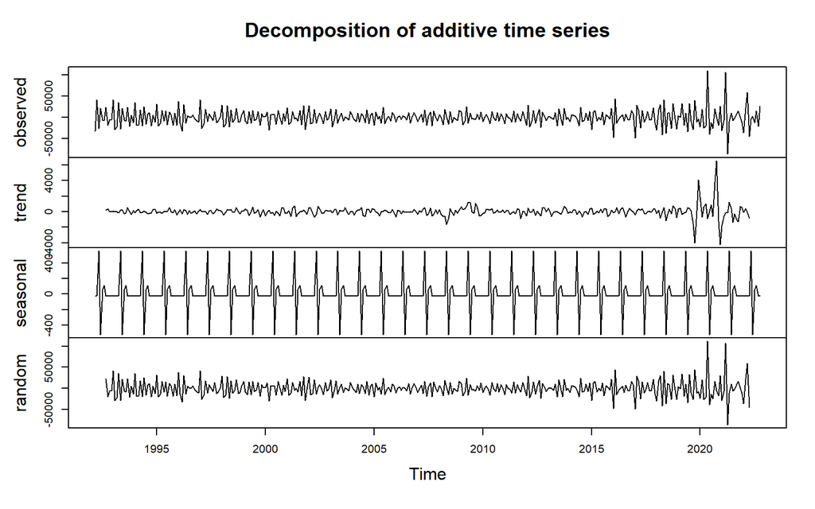

```r
dt2.rs <- diff(wsea.rs, differences= 2)
plot(decompose(dt2.rs))
```